# Challenges of a Bike Sharing Business Model

## Interrelation of Location Related Features

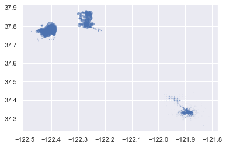

```python
data = (trip_data[trip_data.start_long < -120].
        groupby(['start_lat', 'start_long']).
        count()['bike'].
        reset_index())

plt.scatter(x=data.start_long, y=data.start_lat, s=data.bike/500, alpha=0.5);
```

*Interim Conclusion(s):*

- The three operational areas (San Francisco, East Bay and San Jose) are very disctinct (here: with regard to 'start_latitude' and 'start_longitude')
- Locations in San Jose look a bit strange/"dotty".

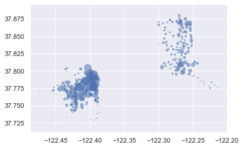

```python
data = (trip_data[(trip_data.start_long < -120) &
                  (trip_data.start_lat > 37.6)].
        groupby(['start_lat', 'start_long']).
        count()['bike'].
        reset_index())

plt.scatter(x=data.start_long, y=data.start_lat, s=data.bike/500, alpha=0.5);
```

*Interim Conclusion(s):*  
Stations in San Francisco are dense (compared to East Bay) having some "heavy traffic" stations.

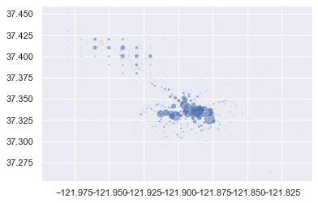

```python
data = (trip_data[(trip_data.start_long < -120) &
                  (trip_data.start_lat < 37.6)].
        groupby(['start_lat', 'start_long']).
        count()['bike'].
        reset_index())

plt.scatter(x=data.start_long, y=data.start_lat, s=data.bike/100, alpha=0.5);
```

*Interim Conclusion(s):*

- There are many rarely used locations in San Jose and a checkboard-like pattern in the northwest.
- The deployment of dockless bikes in San Jose and a probably less precise localization mechanism for that might be an explanation for this pattern.

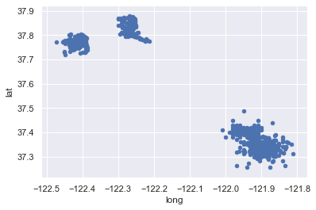

```python
data_start = trip_data[['start_lat', 'start_long']]
data_start.columns = ['lat', 'long']
data_end = trip_data[['end_lat', 'end_long']]
data_end.columns = ['lat', 'long']
data = pd.concat([data_start, data_end], sort=False)
data = data[(data.lat > 35) & (data.lat < 39) & (data.long < -120)]
data = data.drop_duplicates()
data.plot(kind='scatter', x='long', y='lat', color=sb.color_palette()[0]);
```

*Interim Conclusion(s):*  
(Also when taking into account start and end latitude and longitude) the three operational areas (neglecting the outliers outside bay area) are very distinctly identifiable: San Francisco, East Bay and San Jose.

#### Creating 'start_area' and 'end_area' Feature:

```python
for item in ['start', 'end']:
    trip_data[item + '_area'] = 'Other'
    trip_data.loc[(trip_data[item + '_long'] > -122.5) &
                  (trip_data[item + '_long'] < -122.33),
                  item + '_area'] = 'San Francisco'
    trip_data.loc[(trip_data[item + '_long'] >= -122.33) &
                  (trip_data[item + '_long'] < -122.1),
                  item + '_area'] = 'East Bay'
    trip_data.loc[(trip_data[item + '_long'] >= -122.1) &
                  (trip_data[item + '_long'] < -121.8),
                  item + '_area'] = 'San Jose'

trip_data = trip_data[
    ['subscriber', 'bsfa_subscriber', 'gender', 'birth_year',
     'start_time', 'duration',
     'start_area', 'start_lat', 'start_long', 'end_area', 'end_lat', 'end_long',
     'bike']
]
```

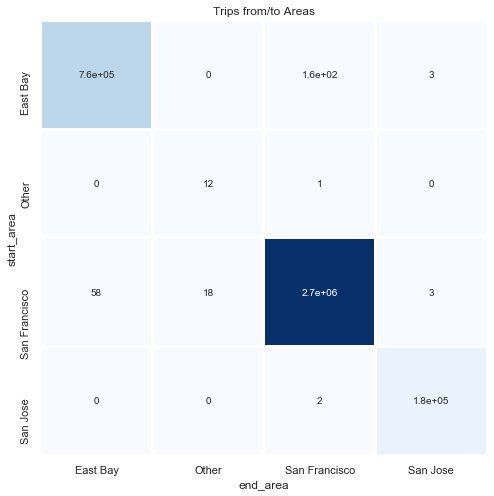

```python
data = trip_data.loc[:, ['start_area', 'end_area']]
data['count'] = 1
data = data.groupby(['start_area', 'end_area']).sum().reset_index()

data = data.pivot(index='start_area', columns='end_area', values='count').fillna(0)

fig, ax = plt.subplots(figsize=(8, 8))
sb.heatmap(data, cmap='Blues', annot=True, ax=ax, cbar=False, linewidth=2)
ax.title.set_text('Trips from/to Areas');
```

*Interim Conclusion(s):*

### Interrelation of User and Location Related Features:

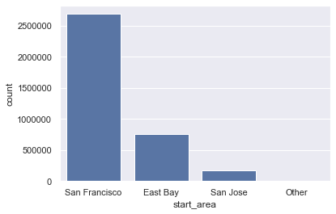

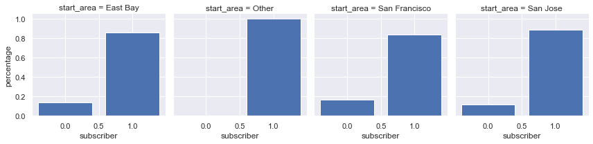

```python
data = trip_data[['subscriber', 'start_area', 'bike']]
sb.countplot(data=data, x='start_area', color=sb.color_palette()[0])
plt.show()

data = pd.crosstab(data['start_area'],data['subscriber']).apply(lambda r: r/r.sum(), axis=1).stack().reset_index()
data.columns = ['start_area', 'subscriber', 'percentage']

g = sb.FacetGrid(data=data, col='start_area')
g.map(plt.bar, 'subscriber', 'percentage');
```

*Interim Conclusion(s):*  
All areas are dominated by subscribers (except the neglectible "Other")

### Interrelation of Time and Location Related Features:

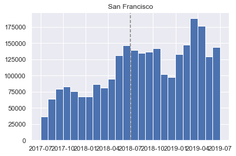

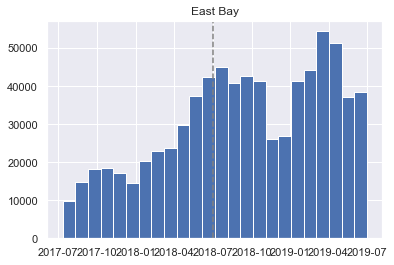

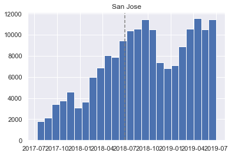

```python
data = trip_data.loc[(trip_data.start_time >= '2017-07-01') &
                     (trip_data.start_time < '2019-07-01')][['start_time', 'start_area']]

for area in ['San Francisco', 'East Bay', 'San Jose']:
    plt.hist(data[data.start_area == area]['start_time'], bins=24)
    plt.title(area)
    plt.axvline(x='07-01-2018', color='grey', linestyle='--')
    plt.show()
```

*Interim Conclusion(s):*

- Growth pattern in San Francisco and East Bay are comparable and show a drop in May 2019 (with a weaker bounce-back in June 2019).
- All three areas are more or less stagnating in the second (full) year.
- (Business-wise smaller) San Jose shows the strongest overall growth and not the drastic drop pattern in May 2019.

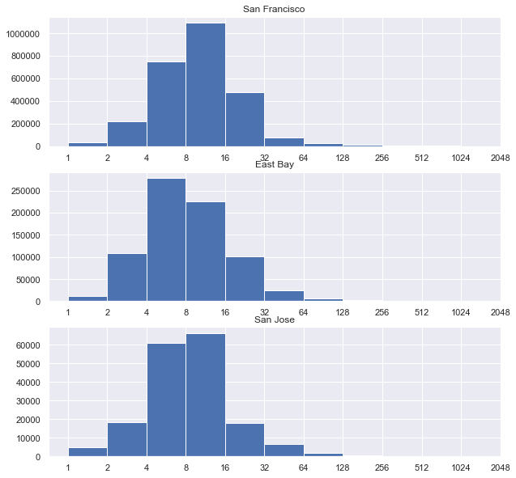

```python
data = trip_data[['start_area', 'duration']].copy()

# Duration in minutes rather than seconds
data.duration = data.duration.dt.total_seconds() / 60

# Bins for every doubling of 1 minute
bin_edges = (2 ** np.arange(0, np.log2(2048), 1))

fig, ax = plt.subplots(nrows=3, figsize=(10, 10))

for counter, area in enumerate(['San Francisco', 'East Bay', 'San Jose']):
    ax[counter].hist(data[data.start_area == area]['duration'], bins=bin_edges)
    ax[counter].set_xscale('log', basex=2)
    xtick_locs = [1, 2, 4, 8, 16, 32, 64, 128, 256, 512, 1024, 2048]
    ax[counter].set_xticks(xtick_locs)
    ax[counter].set_xticklabels(xtick_locs)
    ax[counter].set_title(area)
```

*Interim Conclusion(s):*  
Trips in San Francisco are a bit longer than in East Bay and San Jose. However, there they also tend to be below 16 minutes (15 minutes being a threshold for further charges).

### Interim Summary:

- Non-subscribers show a more homogenous pattern of usage during the day and tend to use the bikes longer.
- Whilst usage of both, subscribers and non-subscribers, dropped in May 2019, only non-subscribers bounced back in June.
- There are three operating areas, San Francisco, East Bay and San Jose, with San Francisco being the most significant one.
- The drop in trips in San Francisco and East Bay in May 2019 also stays on in June 2019, whilst (more growing, but overall least significant) San Jose could recover.

## Multivariate Exploration

### Interrelations of Features Related to Users, Time and Location

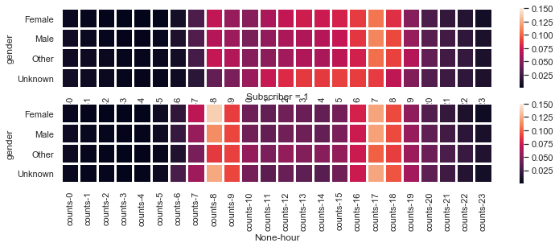

```python
data = trip_data[['subscriber', 'gender', 'start_time']].copy()
data['counts'] = 1

data['hour'] = data.start_time.dt.hour
data = data.groupby(['subscriber', 'gender', 'hour']).sum().unstack().apply(lambda r: r/r.sum(), axis=1)#.apply(lambda r: r/r.sum, axis=1)

fig, ax = plt.subplots(nrows=2, figsize=(12, 4))

for i in range(2):
    sb.heatmap(data.loc[i], ax=ax[i], linewidth=2, vmax=0.15)
    plt.title('Subscriber = ' + str(i));
```

*Interim Conclusion(s):*  
There are some different pattern of usage related to being a subscriber or not and to gender. However, in my eyes, this doesn't seem worth further exploring.

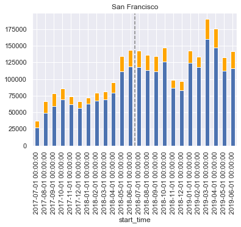

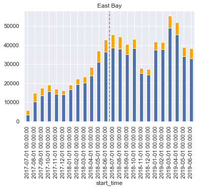

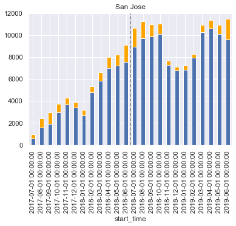

```python
data = trip_data.loc[(trip_data.start_time >= '2017-07-01') &
                     (trip_data.start_time < '2019-07-01')]
data = data[['subscriber', 'start_area', 'start_time']]
data['count'] = 1
data.start_time = data.start_time.astype('datetime64[M]')

areas = ['San Francisco', 'East Bay', 'San Jose']

for area in areas:
    data[data.start_area == area].groupby('start_time').sum()['count'].sort_index().plot(kind='bar', color='orange')
    data[(data.start_area == area) & (data.subscriber == True)].groupby('start_time').sum()['count'].sort_index().plot(kind='bar');
    plt.title(area)
    plt.axvline(x=11.5, color='grey', linestyle='--')
    plt.show()
```

*Interim Conclusion(s):*  
In East Bay and San Jose subscribers are also going down in June 2019 after drop in May 2019, whilst non-subscribers (partially) help to compensate.

```python
trip_data[(trip_data.start_lat == trip_data.end_lat) & (trip_data.start_long == trip_data.end_long)].count() / trip_data.count()
```

```
subscriber         0.028818
bsfa_subscriber    0.028818
gender             0.028818
birth_year         0.024159
start_time         0.028818
duration           0.028818
start_area         0.028818
start_lat          0.028818
start_long         0.028818
end_area           0.028818
end_lat            0.028818
end_long           0.028818
bike               0.028818
dtype: float64
```

*Interim Conclusion(s):*

```python
def make_loc_id(lat, long):
    return str(round(lat, 4)) + '/' + str(round(long, 4))

trip_data['start_loc'] = trip_data[['start_lat','start_long']].apply(lambda x: make_loc_id(*x), axis=1)
trip_data['end_loc'] = trip_data[['end_lat','end_long']].apply(lambda x: make_loc_id(*x), axis=1)

trip_data = trip_data[['subscriber', 'bsfa_subscriber', 'gender', 'birth_year',
                       'start_time', 'duration',
                       'start_area', 'start_loc', 'start_lat', 'start_long',
                       'end_area', 'end_loc', 'end_lat', 'end_long',
                       'bike']]

del(make_loc_id)
```

```python
trip_data[['start_area', 'start_loc']].drop_duplicates().groupby('start_area').count()
```

| start_area | start_loc |
| --- | --- |
| East Bay | 141 |
| Other | 5 |
| San Francisco | 186 |
| San Jose | 1439 |

*Interim Conclusion(s):*

- Whilst there are only dock-bound bikes deployed in San Francisco and East Bay, dockless bikes seem to drive number of destinct start/end-locations in San Jose.
- For analysing usage of docks, it's worth narrowing data down to San Francisco and East Bay.

```python
sfeb_data = trip_data[trip_data.start_area.isin(['San Francisco', 'East Bay']) &
                      trip_data.end_area.isin(['San Francisco', 'East Bay'])].copy()
sfeb_data['counts'] = 1
```

```python
def scatter_sfeb_data(condition=None, cbar_min_max=None, circle_scale_factor=None):

    if condition is not None:
        data = sfeb_data[condition].copy()
    else:
        data = sfeb_data.copy()

    start_loc_freq = (data.
                      groupby(['start_lat', 'start_long']).count()['counts'])
    end_loc_freq = (data.
                    groupby(['end_lat', 'end_long']).
                    count()['counts'])

    loc_freq = pd.DataFrame(pd.concat([start_loc_freq, end_loc_freq],
                                      axis=1, sort=True).
                            sum(axis=1))
    loc_freq.columns = ['freq']

    loc_delta = pd.DataFrame(pd.concat([-start_loc_freq, end_loc_freq],
                                       axis=1, sort=True).
                             sum(axis=1))
    loc_delta.columns = ['delta']

    loc_data = (pd.concat([loc_freq, loc_delta],
                          axis=1).
                fillna(0).
                reset_index())
    loc_data.columns = ['lat', 'long', 'freq', 'delta']
    loc_data['source'] = loc_data.delta / loc_data.freq

    if cbar_min_max is None:
        cbar_min_max = max(-loc_data.source.min(), loc_data.source.max())

    if circle_scale_factor is None:
        circle_scale_factor = loc_data.freq.max() / 250

    plt.figure(figsize=(15, 10))
    ax = plt.gca()
    ax.set_facecolor('dimgrey')
    plt.scatter(x=loc_data.long, y=loc_data.lat,
                s=loc_data.freq / circle_scale_factor,
                c=loc_data.source, cmap='RdBu', vmin=-cbar_min_max, vmax=cbar_min_max,
                alpha=0.8)

    plt.colorbar();
```

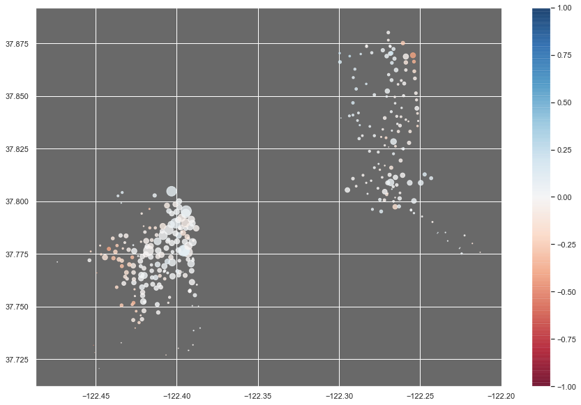

```python
scatter_sfeb_data(cbar_min_max=1)
```

*Interim Conclusion(s):*

- Importance of stations in San Francisco and East Bay varies a lot.
- There are stations where significantly more trips end as started from (and other way around).

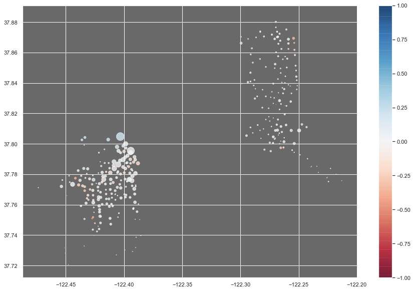

```python
condition = (sfeb_data.subscriber == False)
scatter_sfeb_data(condition, cbar_min_max=1)
```

*Interim Conclusion(s):*  
Pattern of non-subcribers of "start/end" looks comparable to the overall pattern

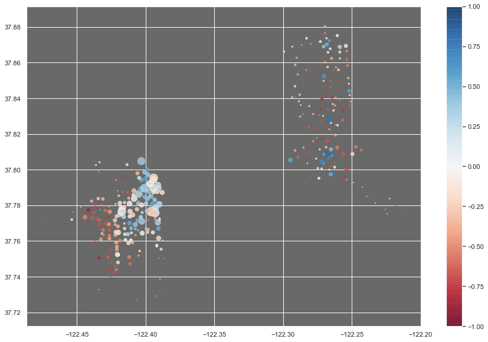

```python
condition = (sfeb_data.start_time.dt.hour < 12)
scatter_sfeb_data(condition, cbar_min_max=1)
```

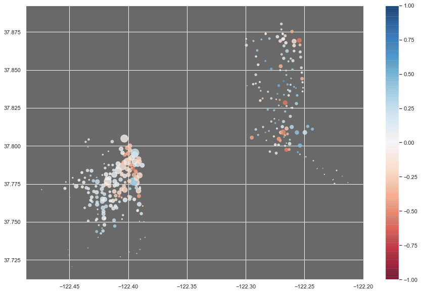

```python
condition = (sfeb_data.start_time.dt.hour >= 12)
scatter_sfeb_data(condition, cbar_min_max=1)
```

*Interim Conclusion(s):*  
Although overall there's a net-gain/loss in some stations, there is also a "daily breathing" from one station to another.

### Interim Summary:

- Bounce back from drop in May 2019 was partly driven by non-subscribers.
- There are stations in San Francisco and East bay that - although traffic is "breathing" - have an overall net-gain/-loss (which drives the need for actively relocating the bikes by baywheels)

## Summary (for digging into in explanatory analysis)

- Overall growth pattern and analysis of dip/slight bounce-back in May/June 2019 is interesting
- Non-subscribers have a more homogenous pattern of bike usage and help to better utilize the bikes during the day
- There's a need for actively relocating the bikes from one station to another.

```python
# Save trip data for use in explanatory analysis
pd.to_pickle(trip_data, r'data/trip_data.pkl', compression='zip')
```